# Advanced Bioinformatics 2025 Assessment

k21007534

2025-04-09

#### Load RNA-seq packages

```r
library(DESeq2)
```

```r
library(ggplot2)
library(pheatmap)
```

# Task 3.1

#### Calculate the sum of all integers from 5 to 55 using base R’s sum() function.

```r
sum(5:55)
```

```
## [1] 1530
```

# Task 3.2

#### Define a reusable function called `sumfun` that takes a number `n` as input

#### This allows us to quickly compute different sums without repeating code.

```r
sumfun <- function(n) {
  sum(5:n)
}
```

#### Use the function to calcualte different values of n:

#### - The sum of integers from 5 to 10

#### - The sum of integers from 5 to 20

#### - The sum of integers from 5 to 100

```r
sum_10 <- sumfun(10)
sum_20 <- sumfun(20)
sum_100 <- sumfun(100)
```

#### Print the results for each value of n

#### These show the output of the custom function for different outputs

```r
sum_10
```

```
## [1] 45
```

```r
sum_20
```

```
## [1] 200
```

```r
sum_100
```

```
## [1] 5040
```

# Task 3.3

#### This task generates the first 12 numbers in the Fibonacci sequence.

#### Create a numeric vector of length 12

#### Format the first two Fibonacci numbers

```r
fib <- numeric(12)
fib[1] <- 1
fib[2] <- 1
```

#### Use a for-loop to calculate each subsequent Fibonacci number

#### Each number is the sum of the previous two numbers

```r
for (i in 3:12) {
  fib[i] <- fib[i - 1] + fib[i - 2]
}
```

#### Print the entire sequence

```r
fib
```

```
##  [1]   1   1   2   3   5   8  13  21  34  55  89 144
```

# Task 3.4

#### This task creates a boxplot using the built-in ‘mtcars’ dataset

#### It visualises distribution of miles per gallon (mpg) based on the number of gears

#### Load ggplot2 for plotting

```r
library(ggplot2)
```

#### Create the boxplot

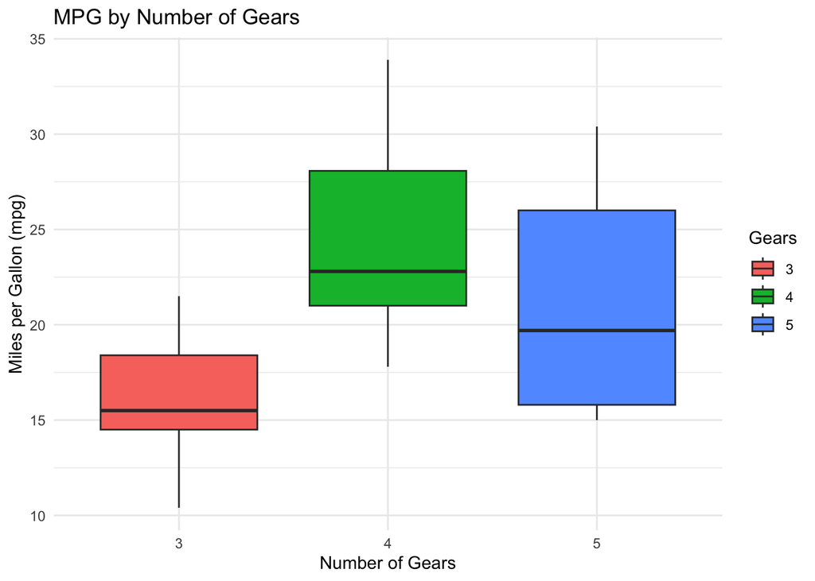

```r
ggplot(mtcars, aes(x = factor(gear), y = mpg, fill = factor(gear))) +
  geom_boxplot() +
  labs(
    title = "MPG by Number of Gears",
    x = "Number of Gears",
    y = "Miles per Gallon (mpg)",
    fill = "Gears"
  ) +
  theme_minimal()
```

# Task 3.5

#### This task involves fitting a linear regression model using the built-in ‘cars’ dataset

#### The relationship between speed (independent variable) and stopping distance (dependent variable)

#### Fit a linear model: predict stopping distance (dist) from car speed

```r
model <- lm(dist ~ speed, data = cars)
```

#### View a summary of the fitted model

#### This includes coefficients, R-squared, p-values and other diagnostics summary (model)

#### The intercept is -17.58 feet

#### The slope is 3.93 feet/mph

```r
summary(model)
```

```
##
## Call:
## lm(formula = dist ~ speed, data = cars)
##
## Residuals:
##     Min      1Q  Median      3Q     Max
## -29.069  -9.525  -2.272   9.215  43.201
##
## Coefficients:
##             Estimate Std. Error t value Pr(>|t|)
## (Intercept) -17.5791     6.7584  -2.601   0.0123 *
## speed         3.9324     0.4155   9.464 1.49e-12 ***
## ---
## Signif. codes:  0 '***' 0.001 '**' 0.01 '*' 0.05 '.' 0.1 ' ' 1
##
## Residual standard error: 15.38 on 48 degrees of freedom
## Multiple R-squared:  0.6511, Adjusted R-squared:  0.6438
## F-statistic: 89.57 on 1 and 48 DF,  p-value: 1.49e-12
```

# Task 3.6

#### Load the ggplot2 library

```r
library(ggplot2)
```

#### Plot using ggplot2

#### Create a scatterplot of speed vs stopping distance

#### Add a linear regression line using geom_smooth()

#### se = TRUE includes the shaded confidence interval

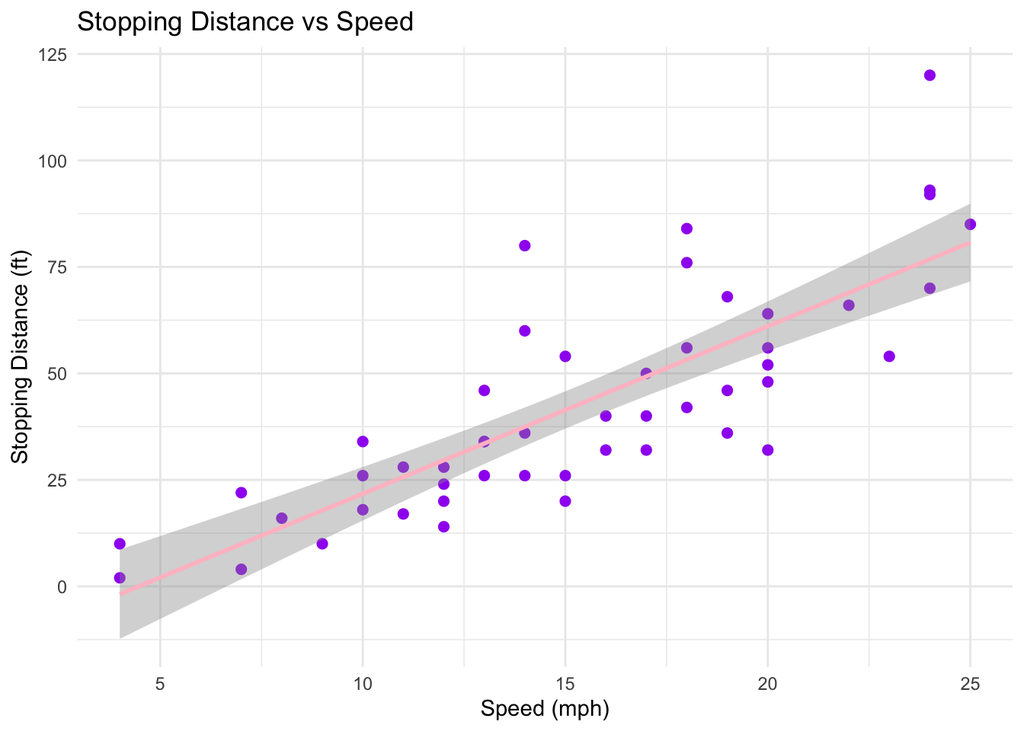

```r
ggplot(cars, aes(x = speed, y = dist)) +
  geom_point(color = "purple", size = 2) +
  geom_smooth(method = "lm", se = TRUE, color = "pink") +
  labs(
    title = "Stopping Distance vs Speed",
    x = "Speed (mph)",
    y = "Stopping Distance (ft)"
  ) +
  theme_minimal()
```

# Task 3.7

#### This task involves creating a quadratic model and plot

#### Create a new variable for speed squared

#### This lets us fit a quadratic model

```r
cars$speed2 <- cars$speed^2
```

#### Fit a quadratic regression model: distance ~ speed + speed^2

```r
reaction_model <- lm(dist ~ speed + speed2, data = cars)
```

#### View the model summary: coefficients, p-values, R-squared

```r
summary(reaction_model)
```

```
##
## Call:
## lm(formula = dist ~ speed + speed2, data = cars)
##
## Residuals:
##     Min      1Q  Median      3Q     Max
## -28.720  -9.184  -3.188   4.628  45.152
##
## Coefficients:
##             Estimate Std. Error t value Pr(>|t|)
## (Intercept)  2.47014   14.81716   0.167    0.868
## speed        0.91329    2.03422   0.449    0.656
## speed2       0.09996    0.06597   1.515    0.136
##
## Residual standard error: 15.18 on 47 degrees of freedom
## Multiple R-squared:  0.6673, Adjusted R-squared:  0.6532
## F-statistic: 47.14 on 2 and 47 DF,  p-value: 5.852e-12
```

#### This is the equation for reference

#### dist = 0.0999593 * speed^2 + 0.9132876 * speed + 2.470138

#### Use the linear regression to estimate the average reaction time for the driver to start breaking

#### Assume braking distance is proportional to the square of speed

#### speed coefficient = 0.91329 ft per mph

#### speed^2 coefficient = 0.09996 (this represents braking distance)

#### Reaction time = 0.91329/1.46667 = 0.6227 seconds

#### The estimated reaction time = 0.6227 seconds

```r
coef(reaction_model)
```

```
## (Intercept)       speed      speed2
##   2.4701378   0.9132876   0.0999593
```

#### Plot the data with a quadratic fit line

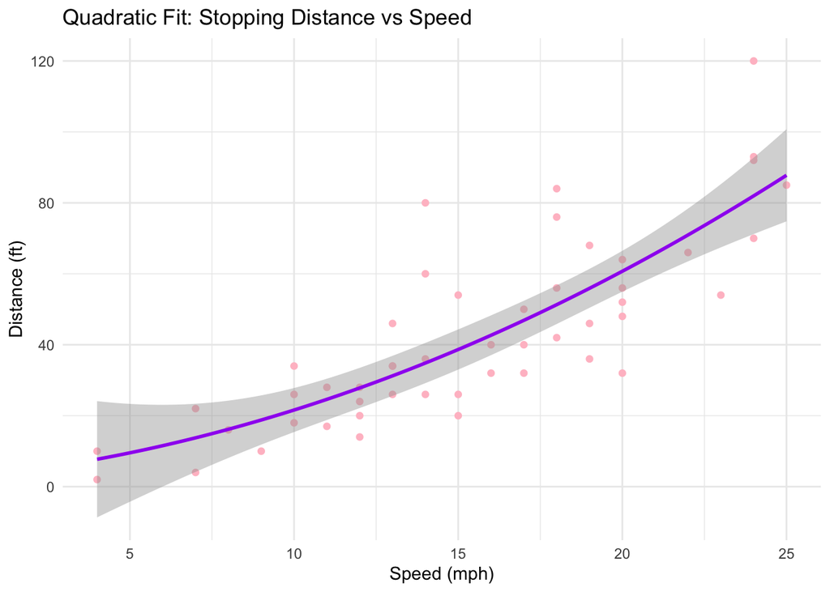

```r
ggplot(cars, aes(x = speed, y = dist)) +
  geom_point(color = "pink") +
  stat_smooth(method = "lm", formula = y ~ x + I(x^2), color = "purple") +
  labs(
    title = "Quadratic Fit: Stopping Distance vs Speed",
    x = "Speed (mph)",
    y = "Distance (ft)"
  ) +
  theme_minimal()
```

# Task 3.8

#### Set working directory to where the RNA-seq data files are stored

#### This allows R to find the input files when loading them

```r
setwd("~/Desktop/LMS_RNAseq_short-master-2023-final/course/exercises/data")
```

#### Confirm that the count data file exists in the working directory

```r
file.exists("exercise1_counts.csv")
```

```
## [1] TRUE
```

#### Load the RNA-seq count data as a data frame

#### The first column is used as row names (genes)

```r
count_data <- read.csv("exercise1_counts.csv", row.names = 1)
```

#### Load the sample description

#### This file contains metadata about the sampples

#### It is tab-separated and also uses the first column as row names

```r
sample_info <- read.table("exercise1_sample_description.info",
                          header = TRUE,
                          sep = "\t",
                          row.names = 1)
```

#### Preview the first few rows of each dataset to ensure that they are loaded correctly

```r
head(count_data)
```

```
##           control_FFa1.bam control_FFa2.bam control_FFa3.bam mutant_KOa1.bam
## 497097                  16               16                0              21
## 100503874               20                0                0              64
## 100038431                0                0                2               0
## 19888                   11                0               10             113
## 20671                   14               16                0              40
## 27395                  465              193              596             436
##           mutant_KOa2.bam mutant_KOa3.bam mutant_KOb1.bam mutant_KOb2.bam
## 497097                 16              27              20               0
## 100503874               0               4               5               0
## 100038431               0               8               0               0
## 19888                   0              26              14               6
## 20671                   8              33              33              12
## 27395                 686             572            1378            1901
##           mutant_KOb3.bam
## 497097                  2
## 100503874               2
## 100038431               0
## 19888                  16
## 20671                  24
## 27395                1553
```

```r
head(sample_info)
```

```
##                     sample condition batch
## control_FFa1.bam      FFa1       FFa     a
## control_FFa2.bam      FFa2       FFa     b
## control_FFa3.bam      FFa3       FFa     c
## TMC_mutant_KOa1.bam   KOa1       KOa     a
## TMC_mutant_KOa2.bam   KOa2       KOa     b
## TMC_mutant_KOa3.bam   KOa3       KOa     c
```

# Task 3.9

#### Assign sample_info to col_data for use in DESeq2

```r
col_data <- sample_info
```

#### Check the dimensions of the count matrix and the sample metadata

#### This ensures that they match: number of columns in count_data should equal the rows in col_data

```r
dim(col_data)
```

```
## [1] 9 3
```

```r
dim(count_data)
```

```
## [1] 26301     9
```

# Task 3.10

#### This taks involves creating the DESeq2 Dataset object

#### Load the DESeq2 package for RNA-seq differential expression analysis

```r
library(DESeq2)
```

#### Check whether the column names of the count data match the row names of the sample metadata

#### This confirms whether the sample names match between metadata and count matrix

```r
all(colnames(count_data) == rownames(col_data))
```

```
## [1] FALSE
```

#### Remove the “TMC_” prefix from sample names in metadata using gsub

#### This step makes the row names in col_data match the column names in count_data

```r
rownames(col_data) <- gsub("^TMC_", "", rownames(col_data))
```

#### Confirm sample names match between metadata and count matrix exactly

```r
all(colnames(count_data) == rownames(col_data))
```

```
## [1] TRUE
```

#### Convert the ‘condition’ column in the metadata to a factor

#### This is necessary for DESeq2 to correctly treat it as a categorical variable

```r
col_data$condition <- as.factor(col_data$condition)
```

#### Create DESeq2 dataset object using the count data and the sample metadata

#### This design formula indicates that the effect of ‘condition’ will be analysed

```r
dds <- DESeqDataSetFromMatrix(countData = count_data,
                              colData = col_data,
                              design = ~ condition)
```

#### View a summary of the DESeqDataSet object

#### This shows how many samples and genes are in the dataset

```r
dds
```

```
## class: DESeqDataSet
## dim: 26301 9
## metadata(1): version
## assays(1): counts
## rownames(26301): 497097 100503874 ... 100040384 100040400
## rowData names(0):
## colnames(9): control_FFa1.bam control_FFa2.bam ... mutant_KOb2.bam
##   mutant_KOb3.bam
## colData names(3): sample condition batch
```

# Task 3.11

#### This task invovles performing rlog and VST transformations

#### Perform regularised log (rlog) transformation on the dataset

#### rlog is useful for visualisations and clustering when sample size is small

```r
rld <- rlog(dds, blind = FALSE)
```

#### Perform VST (variance stabilizing transformation)

#### VST is another way to normalise count data and is especially useful for PCA and clustering

```r
vsd <- vst(dds, blind = FALSE)
```

#### View the transformed values (log-scale counts) for the first few genes/samples

#### This confirms that the transformation worked and gives you a sense of the data range

```r
head(assay(rld))
```

```
##           control_FFa1.bam control_FFa2.bam control_FFa3.bam mutant_KOa1.bam
## 497097            3.862085        3.9756435        3.5996617       3.9191325
## 100503874         3.317795        2.9544860        2.9441990       3.7910935
## 100038431         0.182533        0.1831006        0.2094969       0.1824948
## 19888             3.971878        3.7475024        3.9183635       4.9775805
## 20671             4.222344        4.3682499        3.9829072       4.5220382
## 27395             9.191113        8.7377660        9.2633822       9.0798129
##           mutant_KOa2.bam mutant_KOa3.bam mutant_KOb1.bam mutant_KOb2.bam
## 497097           3.856098       3.9824225       3.7824084       3.5937326
## 100503874        2.946261       3.0295445       3.0023509       2.9384760
## 100038431        0.182505       0.2963647       0.1820314       0.1819638
## 19888            3.730916       4.1940961       3.8958253       3.7881879
## 20671            4.125567       4.4395618       4.2720451       4.0829957
## 27395            9.591000       9.3449464       9.6904873       9.9158291
##           mutant_KOb3.bam
## 497097           3.620299
## 100503874        2.970507
## 100038431        0.182127
## 19888            3.947804
## 20671            4.233484
## 27395            9.999862
```

```r
head(assay(vsd))
```

```
##           control_FFa1.bam control_FFa2.bam control_FFa3.bam mutant_KOa1.bam
## 497097            8.064601         8.177150         7.615857        8.119824
## 100503874         8.117068         7.615857         7.615857        8.486846
## 100038431         7.615857         7.615857         7.761233        7.615857
## 19888             7.988401         7.615857         7.940381        8.760589
## 20671             8.035828         8.177150         7.615857        8.308274
## 27395             9.823116         9.451296         9.885198        9.729670
##           mutant_KOa2.bam mutant_KOa3.bam mutant_KOb1.bam mutant_KOb2.bam
## 497097           8.058511        8.178287        7.981197        7.615857
## 100503874        7.615857        7.833504        7.798893        7.615857
## 100038431        7.615857        7.923365        7.615857        7.615857
## 19888            7.615857        8.167901        7.921766        7.804383
## 20671            7.929472        8.236789        8.084339        7.882284
## 27395           10.176212        9.955913       10.267286       10.479935
##           mutant_KOb3.bam
## 497097           7.740870
## 100503874        7.740870
## 100038431        7.615857
## 19888            7.968677
## 20671            8.047438
## 27395           10.561515
```

# Task 3.12

#### Download the binary package pheatmap for heatmap plotting

```r
library(pheatmap)
```

#### Identify the top 40 most highly expressed genes based on rlog-transformed values

```r
top_genes <- head(order(rowMeans(assay(rld)), decreasing = TRUE), 40)
```

#### Generate the heatmap using rlog-transformed data

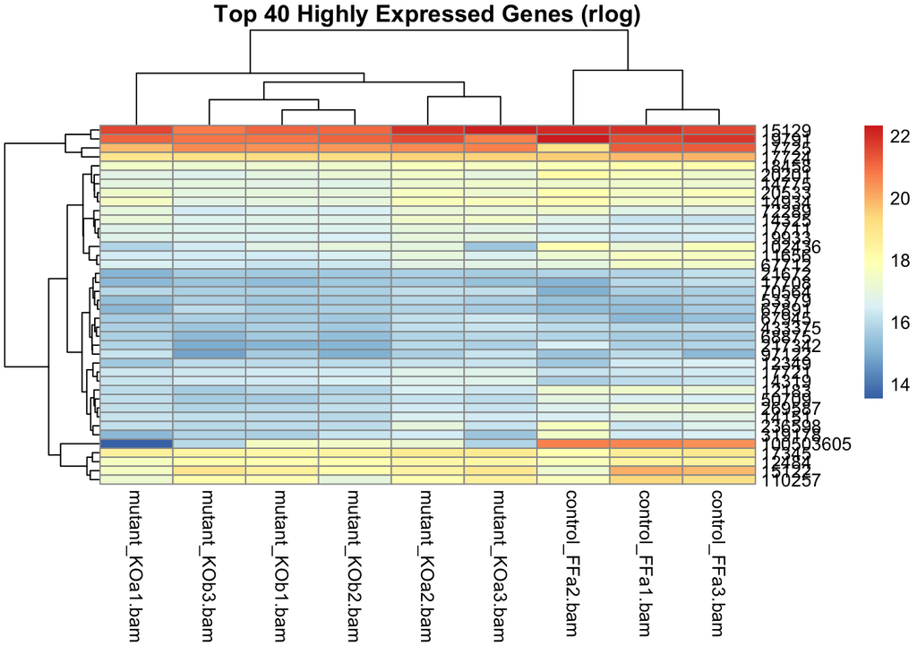

```r
pheatmap(assay(rld)[top_genes, ],
         cluster_rows = TRUE,
         cluster_cols = TRUE,
         show_rownames = TRUE,
         show_colnames = TRUE,
         main = "Top 40 Highly Expressed Genes (rlog)")
```

#### Generate the heatmap using VST-transformed data

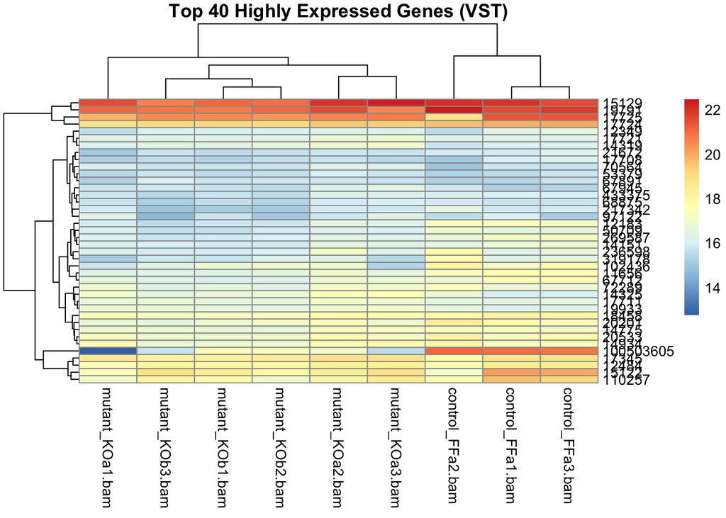

```r
pheatmap(assay(vsd)[top_genes, ],
         cluster_rows = TRUE,
         cluster_cols = TRUE,
         show_rownames = TRUE,
         show_colnames = TRUE,
         main = "Top 40 Highly Expressed Genes (VST)")
```

# Task 3.13

#### Compute the Euclidean distance between samples using rlog data

```r
sample_dists <- dist(t(assay(rld)))
```

#### Convert distance object to matrix and label with sample conditions

#### Plot the heatmap of sample distances

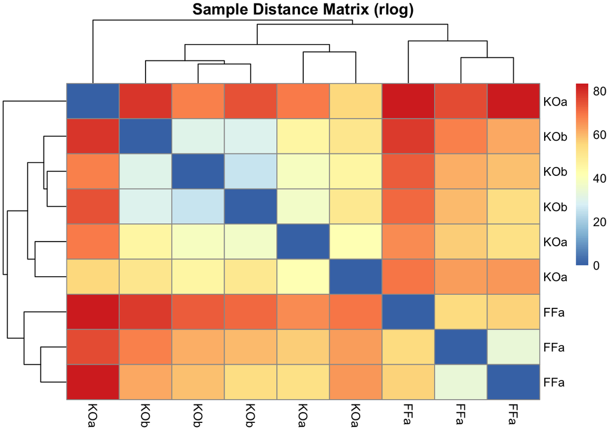

```r
sample_dist_matrix <- as.matrix(sample_dists)
rownames(sample_dist_matrix) <- col_data$condition
colnames(sample_dist_matrix) <- col_data$condition

pheatmap(sample_dist_matrix,
         clustering_distance_rows = sample_dists,
         clustering_distance_cols = sample_dists,
         main = "Sample Distance Matrix (rlog)")
```

# Task 3.14

#### This task involves principal component analysis using rlog-transformed data

#### Perform the principal component analysis (PCA) on rlog-transformed data

```r
pca_rlog <- prcomp(t(assay(rld)))
```

#### Plot the PCA

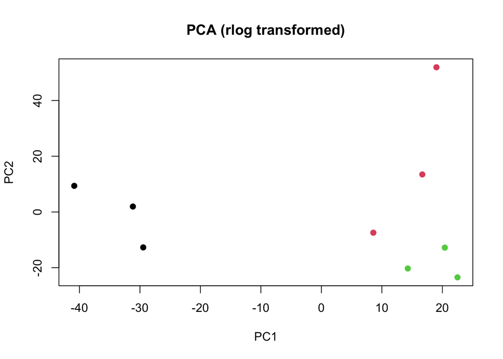

```r
plot(pca_rlog$x[,1:2], col=as.factor(col_data$condition),
     pch=19, main="PCA (rlog transformed)")
```

#### Calculate the percentage of variance explained by each principal component (PC)

```r
pca_var <- pca_rlog$sdev^2
pca_var_percent <- round(100 * pca_var / sum(pca_var), 2)
```

#### Show variance explained by PC1 and PC2

```r
pca_var_percent[1:2]
```

```
## [1] 37.21 29.98
```

# Task 3.15

#### This task involves principal component analysis using VST-transformed data

#### Perform PCA on VST-transformed data

```r
pca_vst <- prcomp(t(assay(vsd)))
```

#### Calcualte and compare the percentage of variance explained

```r
pca_vst_var <- pca_vst$sdev^2
pca_vst_var_percent <- round(100 * pca_vst_var / sum(pca_vst_var), 2)
```

#### Plot the PCA using VST data

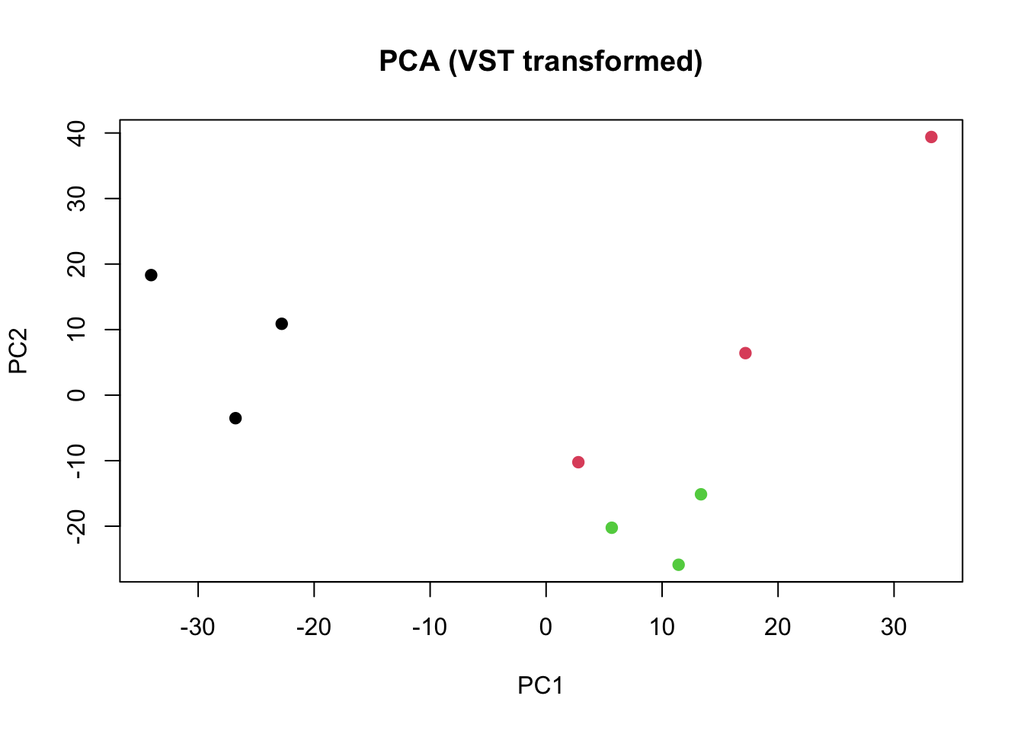

```r
plot(pca_vst$x[,1:2],
     col = as.factor(col_data$condition),
     pch = 19,
     main = "PCA (VST transformed)")
```

#### Show variance explained by PC1 and PC2

```r
pca_vst_var_percent[1:2]
```

```
## [1] 34.38 28.81
```

# Task 3.16

#### This taskinvolves reading in the two Myc Mel peakset replicates and create the common peakset

#### Load ChIPseeker and other relevant packages

#### Change working directory to ChIP-seq data

```r
knitr::opts_knit$set(root.dir = "~/Desktop/LMS_ChIPseq_short-master-2023-final/course/data/MacsPeaks")
```

#### Load the necessary packages for ChIP-seq analysis

```r
library(ChIPseeker)
library(GenomicRanges)
library(BSgenome.Mmusculus.UCSC.mm10)
library(Biostrings)
```

#### Read in the two MACS2 peak replicate files

```r
rep1 <- readPeakFile("/Users/lamiajerin/Desktop/LMS_ChIPseq_short-master-2023-final/course/data/MacsPeaks/mycmelrep1_peaks.xls")
rep2 <- readPeakFile("/Users/lamiajerin/Desktop/LMS_ChIPseq_short-master-2023-final/course/data/MacsPeaks/mycmelrep2_peaks.xls")
```

#### Find the overlapping peaks between the two replicates - where both replicates show a peak at the same genomic location

```r
common_peaks <- GenomicRanges::intersect(rep1, rep2)
```

#### Output the number of overlapping peaks

```r
length(common_peaks)
```

```
## [1] 32465
```

# Task 3.17

#### Use subsetByOverlaps to find overlapping peaks from rep1 that also appear in rep2 - this returns the exact overlap between two peak sets

#### This keeps important metadata like fold_enrichment

```r
common_peaks <- subsetByOverlaps(rep1, rep2)
```

#### Check what metadata columns are available to rank by

```r
colnames(mcols(common_peaks))
```

```
## [1] "length"          "abs_summit"      "pileup"          "X.log10.pvalue."
## [5] "fold_enrichment" "X.log10.qvalue." "name"
```

#### Rank peaks by fold enrichment in descending order

```r
ranked_peaks <- common_peaks[order(mcols(common_peaks)$fold_enrichment, decreasing = TRUE)]
```

#### Select the top 500 most enriched peaks

```r
top500 <- ranked_peaks[1:500]
```

#### Resize each peak to a standardised width of 200bp, centered on peak midpoint

```r
top500_resized <- resize(top500, width = 200, fix = "center")
```

#### View a summary of the resized peaks

```r
top500_resized
```

```
## GRanges object with 500 ranges and 7 metadata columns:
##         seqnames              ranges strand |    length abs_summit    pileup
##            <Rle>           <IRanges>  <Rle> | <integer>  <integer> <numeric>
##     [1]        4   45966312-45966511      * |      1430   45966486       248
##     [2]        9   21156572-21156771      * |      2848   21157016       228
##     [3]       12 114345800-114345999      * |      1480  114345880       183
##     [4]        3   87847244-87847443      * |      1017   87847065       205
##     [5]        5 136578227-136578426      * |       746  136578211       175
##     ...      ...                 ...    ... .       ...        ...       ...
##   [496]        3   79395461-79395660      * |      1718   79395316        66
##   [497]        5 116009877-116010076      * |      1609  116009467        98
##   [498]       15   76093878-76094077      * |       674   76094016        55
##   [499]       15   42263527-42263726      * |       927   42263740        54
##   [500]        9   22234273-22234472      * |      1147   22234392        76
##         X.log10.pvalue. fold_enrichment X.log10.qvalue.                  name
##               <numeric>       <numeric>       <numeric>           <character>
##     [1]         488.149        123.1159         479.841 mycmelrep1_peak_33018
##     [2]         437.832        111.5354         430.369 mycmelrep1_peak_48303
##     [3]         360.959        104.7455         354.200 mycmelrep1_peak_11995
##     [4]         378.718         96.9533         371.892 mycmelrep1_peak_30691
##     [5]         336.006         96.8103         329.475 mycmelrep1_peak_38571
##     ...             ...             ...             ...                   ...
##   [496]         89.8583         30.5057         85.5289 mycmelrep1_peak_30563
##   [497]        122.0812         30.4665        117.3935 mycmelrep1_peak_37888
##   [498]         79.4952         30.4607         75.2962 mycmelrep1_peak_17257
##   [499]         78.5476         30.4243         74.3623 mycmelrep1_peak_16618
##   [500]         99.5168         30.3900         95.0801 mycmelrep1_peak_48715
##   -------
##   seqinfo: 22 sequences from an unspecified genome; no seqlengths
```

# Task 3.18

#### Load the required packages if it hasn’t been done already

```r
library(BSgenome.Mmusculus.UCSC.mm10)
library(Biostrings)
library(GenomicRanges)
```

#### Ensure chromosome naming styles match between peaks and genome - this will convert “1”,“2” to “chr1”,“chr2”, to match the genome

```r
seqlevelsStyle(top500_resized) <- "UCSC"
```

#### Trim ranges so they don’t extend beyond chromosome boundaries

```r
top500_trimmed <- trim(top500_resized)
```

#### Filter to keep only valid ranges - it needs to exactly 200bp wide and match known chromosomes in the genome

```r
top500_final <- top500_trimmed[
  width(top500_trimmed) == 200 &
  as.character(seqnames(top500_trimmed)) %in% seqnames(BSgenome.Mmusculus.UCSC.mm10)
]
```

#### Check how many valid peaks remain

```r
length(top500_final)
```

```
## [1] 500
```

#### Create an empty GRangesList to store only “good” regions (ones that won’t error)

```r
good_ranges <- GRangesList()
```

#### Loop through each peak and only keep the ones that work with getSeq()

```r
for (i in seq_along(top500_final)) {
  range_i <- top500_final[i]
  tryCatch({
    getSeq(BSgenome.Mmusculus.UCSC.mm10, range_i)
    good_ranges <- c(good_ranges, range_i)
  }, error = function(e) {
  })
}
```

#### Combine the good ranges into a final object

```r
 top500_clean <- unlist(good_ranges)
```

#### Confirm the number of usable peaks

```r
length(top500_clean)
```

```
## [1] 494
```

#### Extract sequences from the genome using only safe, valid ranges

```r
sequences <- getSeq(BSgenome.Mmusculus.UCSC.mm10, top500_clean)
```

#### Name the sequences for FASTA headers

```r
names(sequences) <- paste0("peak_", seq_along(sequences))
```

#### Write to a FASTA file in your working directory

```r
writeXStringSet(sequences, "top500_myc_peaks.fa")
```

# Task 3.19